# 01-roulette-simulation

Yasi Wang

10/5/2019

[figure not shown]

# Introduction

## Roulette wheel

The Roulette wheel is a casino game which is very popular around the world. A roulette table is composed of 38 (or 37) evenly sized pockets on a wheel. The pockets are colored red, black, or green. The pockets are also numbered. Roulette is a game of chance in which a pocket is randomly selected.

Gamblers have several ways to bet. They can bet on individual numbers, various groupings of numbers, the colors red or black, whether the number is odd or even, or whether the numbers are high or low. If the ball falls into a pocket that belongs to the house, all the players lose and the house collects all the bets.

## Martingale stragegy

There is a wide range of strategies that players follow when they play Roulette, and the most common strategy seems to be the Martingale Strategy, which consists of doubling bets post-loss in a 50/50 chance game.

Martingale Strategy bets can be on black or red, even or odd, and the specific number. If the player wins, he bets again with the same size wager. If the player loses, he doubles his previous wager amount and places the same bet again. For example, if the player bet 1 dollar on red numbers in his first bet and lost, his second bet will be 2 dollars on red numbers again. If the player wins on the second bet, he pockets the cash and reverts back to his original 1 dollar bet for the next round. If the player loses on the second bet, he must double his bet once more and try again.

[figure not shown]

Consider the following sequence {Black, Black, Black, Red}:

| Play | Wager | Outcome | Earnings |
| --- | --- | --- | --- |
| 1 | 1 | Black | -1 |
| 2 | 2 | Black | -3 |
| 3 | 4 | Black | -7 |
| 4 | 8 | Red | +1 |

It seems tha the Martingale strategy always end in positive earnings, regardless of how unlucky a string of spins may be. Is it truely profitable?

# Simulation

In order to better get insight of Roulette game, we created the repeated simulations to demonstrate the process of Roulette gambling using Martingale strategy.

First, We identify four parameters and their starting value. They are:

| Parameter | Description | Starting value |
| --- | --- | --- |
| **B** | Starting budget | $200 |
| **W** | Winnings threshold for stopping | $300 (Starting budget + $100 winnings) |
| **L** | Time threshold for stopping | 1000 plays |
| **M** | Casino’s maximum wager | $100 |

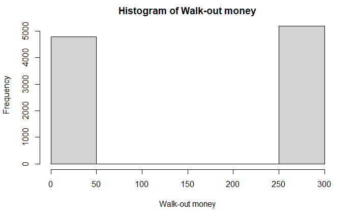

After 10000 times simulation, we can tell that you can earn extra cash in 5201 times and lost money in the rest of the times. The estimated earnings through out the 10000 times is losing 44 dollars.

```r
# Estimated probability of walking out with extra cash
mean(walk_out_money > 200)
```

```
[1] 0.5201
```

```r
# Estimated earnings
mean(walk_out_money - 200)
```

```
[1] -43.9844
```

### Examples of gambler earnings/losses over time

I demonstrate some patterns of grambler earnings over a series of wagers at the roulette wheel.

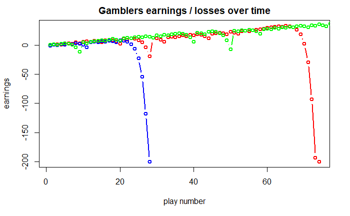

# Analysis

For further analysis, I’ll show how changing a parameter of the simulation does or does not have an impact on average earnings.

### Budget

When we set the budget from 10 to 300 (budget has to be lower than winning threshold), average earnings will first decrease and then increase with the increase of budget.

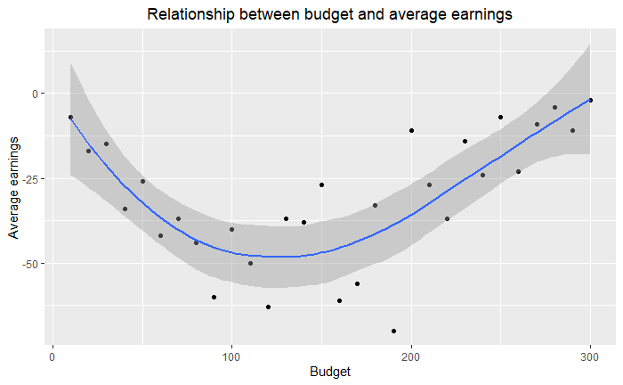

### Winning threshold

When we set the winning threshold from 220 to 840, the average earnings will decrease.

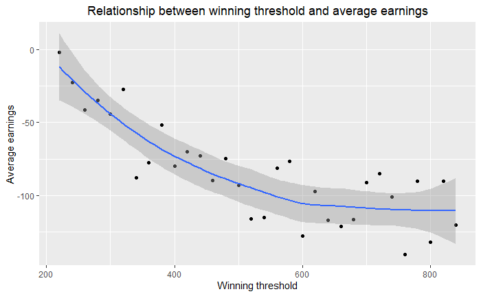

### Time threshold (Number of playes)

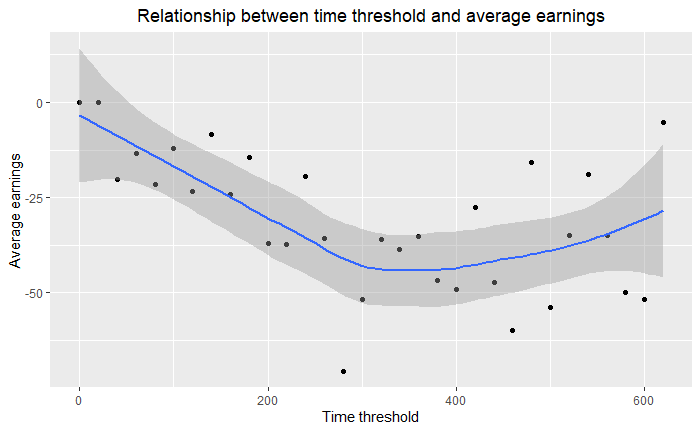

### Maximum wagers

When we set Maximum wagers from 0 to 310, we can find some slight increase.

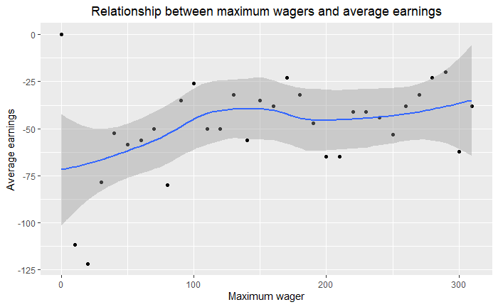

## The average number of plays

In order to estimate the average number of plays before stopping, we need to find the number of plays in each series of play. We can easily know that the length of the one_series function represents the number of plays. This is because one_series function return the vector which stores all the budget over series of plays. If we count the number of budget, we can get the number of plays in this series.

Then, we can simulate 100 times and average the results. It shows that the average number of plays is 200 times.

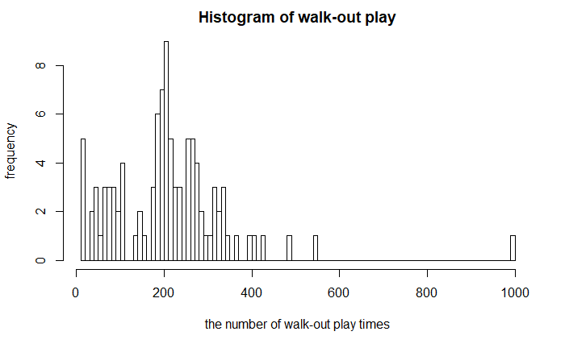

```r
# Estimated playing times
mean(walk_out_play)
```

[output not shown]

# Limitations of the simulation

1. When we do the simulation, we need a good theory and causal hypotheses.
2. The use of simulation requires very little time and resources. We don not need to do the experiment and collect the data in the real world. The only thing we need to do is to choose a theory and set up the parameters. But there still exists some skepticism. This is because most of today’s analysis is based on reporting and building statistical models to describe what has happened in the past.
3. Even though simulation doesn’t require data, the validation of simulation often requires multiple data sources to achieve the confidence in its representation of real-world dynamics.
4. Simulation need to take a lot of data to be input, so it usually need the computer with higher memory and processor speed.

# Sources of uncertainty

1. The player’s risk preference will affect the result. If he prefers risk aversion, he will stop playing afer losing a small amount of money.
2. The player’s mood is changing in the whole process of playing. This will affect the strategy he choose to use.